# Python Comparison

and some nearest neighbor comparisons

This is part of the documentation for uwot.

This page is a gallery of images comparing the output of `uwot` version 0.1.3 to the [Python `UMAP` package](https://github.com/lmcinnes/umap) version 0.3.8. In an ideal world, this wouldn’t be a very exciting document, as it would exist to demonstrate that `uwot` results resemble those from the Python implementation.

However, there are a couple of examples that highlight some differences between the implementations. It’s still not that exciting, but there may be some information of use to anyone using `uwot` and possibly some implications for users of t-SNE packages. To distinguish between the general technique of UMAP and the its specific implementation in the Python package of the same name, I’ll refer to the Python implementation with the formatting `UMAP`.

For details on the datasets, see the [UMAP examples gallery](https://jlmelville.github.io/uwot/umap-examples.html). The `uwot` results have been re-run for the images here using different random seeds, but they should resemble the `uwot` output on that page.

The datasets originated in R, mostly being loaded via the [snedata package](https://github.com/jlmelville/snedata). I then exported them to CSV, before reading them into Python. UMAP version 0.3.8 was used to generate the embeddings, using all default settings. The embeddings were then written to CSV and read back into R for visualization.

The `uwot` output also used default settings with the following exceptions: `pca = 100` was used to reduce the dimensionality to a maximum of 100 columns (data was mean-centered as part of this process, but not rescaled), because the Annoy nearest neighbor search can be very slow for high-dimensional data. `UMAP`’s [nearest neighbor search](https://github.com/lmcinnes/pynndescent) seems less affected by dimensionality. Also, `min_dist = 0.1`, which is the default for the Python UMAP. `uwot` uses a default of `min_dist = 0.01`. Why? I would love to tell you, but I think I just made a mistake when I set the `uwot` defaults. Therefore, the defaults will probably change in some later version of `uwot`. Fortunately, this doesn’t make a perceptible practical difference, but I will use the Python default of `min_dist = 0.1` in the following results.

There is also a potential difference in initialization. Both packages use a spectral initialization if possible, but differ if the input graph contains more than one component: `UMAP` attempts a meta-embedding of the two separate components, where `uwot` abandons a spectral approach and falls back to using PCA (followed by rescaling the output to a standard deviation of 1 for each axis). This affects the following datasets: `iris`, `coil20`, `coil100`, `norb` and `tasic2018`.

```r
set.seed(42)
iris_umap <- umap(iris, pca = 100, min_dist = 0.1)
```

```python
# iris X data read from CSV
iris_umap = umap.UMAP().fit_transform(iris_x)
```

Below the results on the left are for the `uwot` output. The image on the right is from `UMAP`. I present most of these results without comment because they seem to be very similar to each other. There are two exceptions, for the small NORB dataset (`norb`) and the gene expression dataset `macosko2015`, which will be discussed in their section.

## Results

### iris

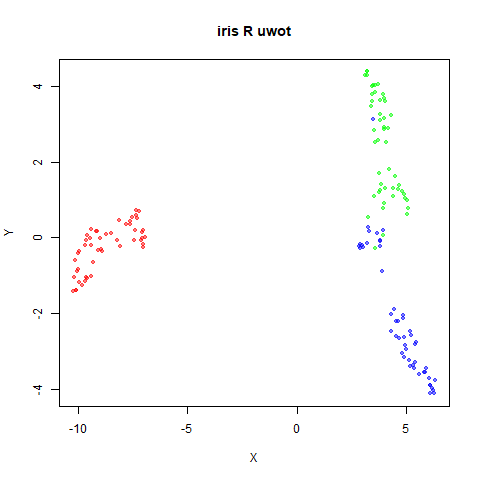

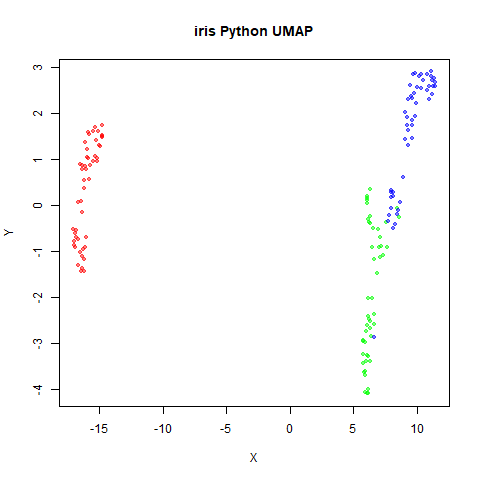

### s1k

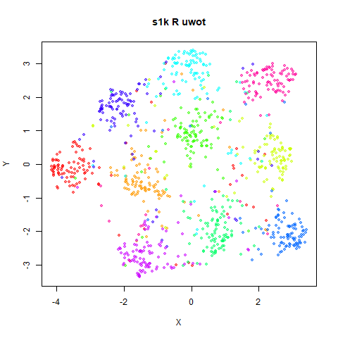

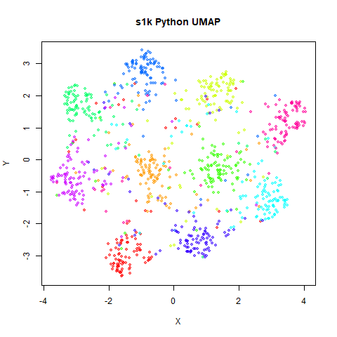

### oli

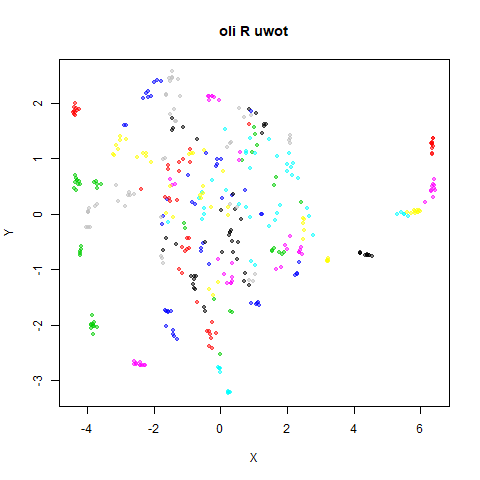

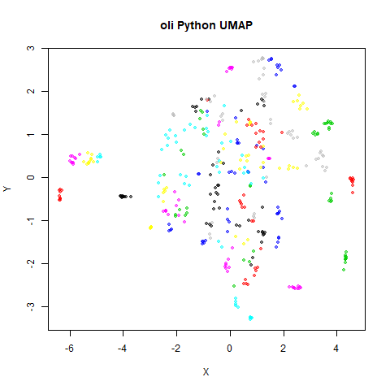

### frey

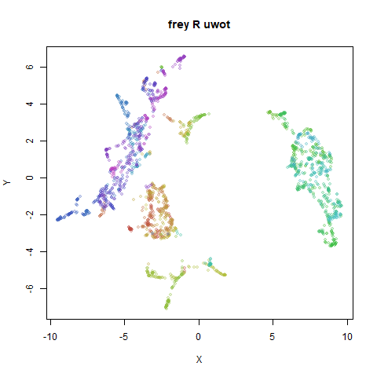

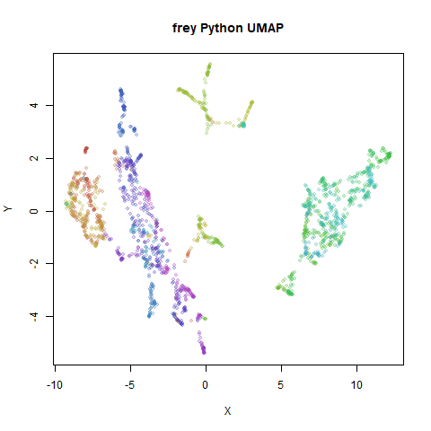

### coil20

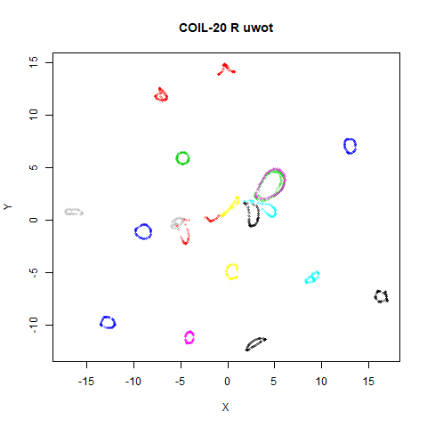

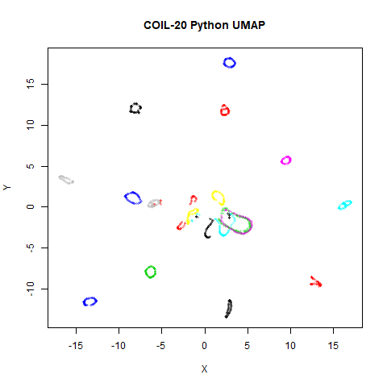

### coil100

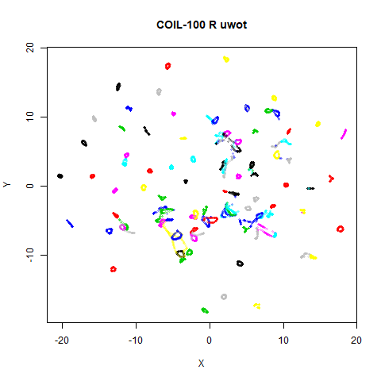

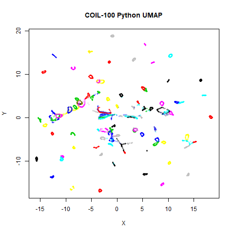

### mnist

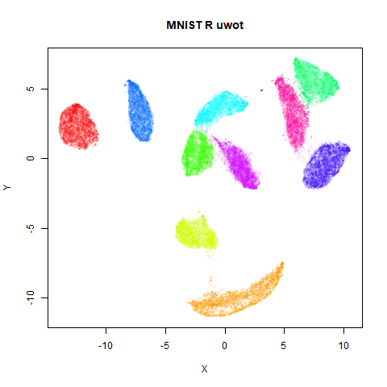

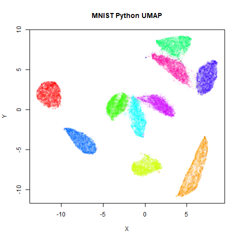

### fashion

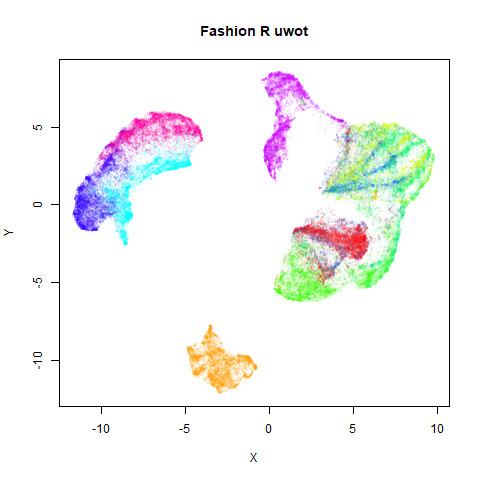

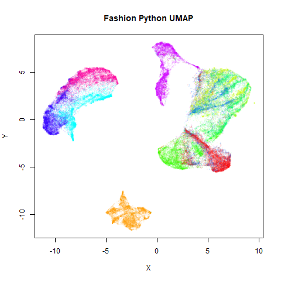

### kuzushiji

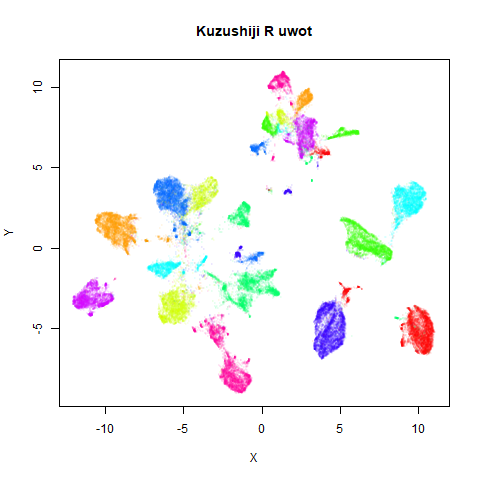

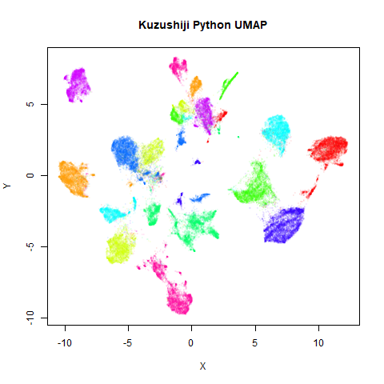

### norb

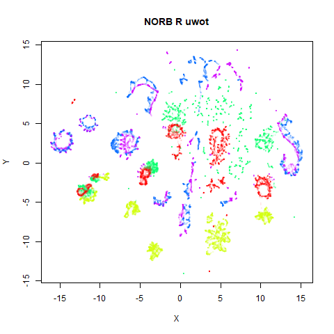

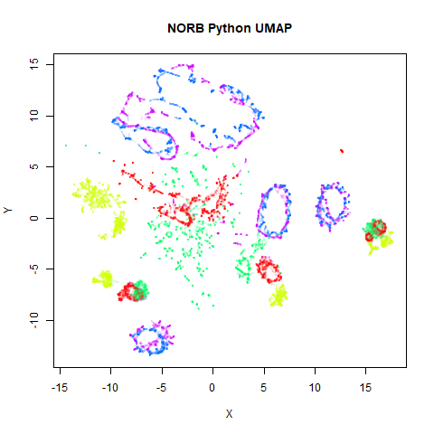

Here’s a result that seems worth commenting on. The `uwot` results show slightly less structure, a large blue loop seems to have been broken up.

I suspect that the PCA preprocessing to 100 dimensions as used by `uwot` is too aggressive here and might be throwing away too much of the variance in the dataset. Compared to the ground truth 15 nearest neighbors using FNN, Annoy results with `pca = 100` are 82% accurate. Without PCA, this accuracy goes up to 99% and the `uwot` results are much closer to the `UMAP` results. This is the image below, on the left. Meanwhile, if you use the PCA results as input to `UMAP`, the output now looks a bit more like the `uwot` results. That’s the image on the lower right.

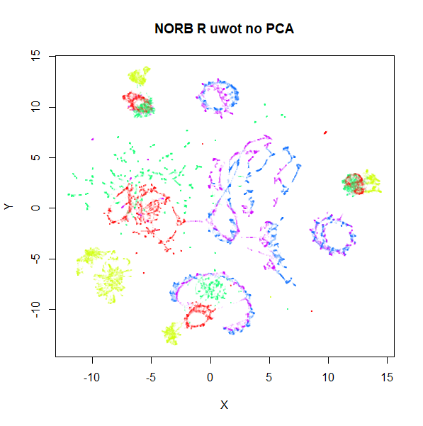

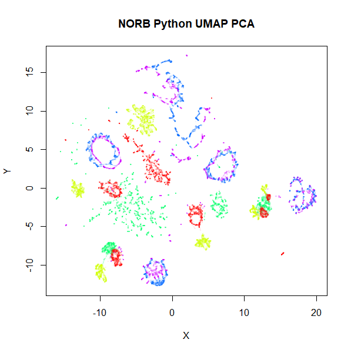

Unfortunately, the very high dimensionality of `norb` makes running Annoy on it directly very slow indeed: with a single-thread, it took 4 and a half hours, versus around 5 minutes in the PCA case. We will revisit nearest neighbor accuracies later.

Note also that `norb` is one of the datasets where the graph contains two separate components, so the initialization of the output coordinates is different between `uwot` and `UMAP`, with `UMAP`’s “meta-embedding” approach better at retaining local structure.

### tasic2018

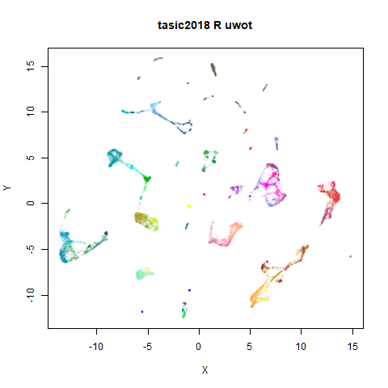

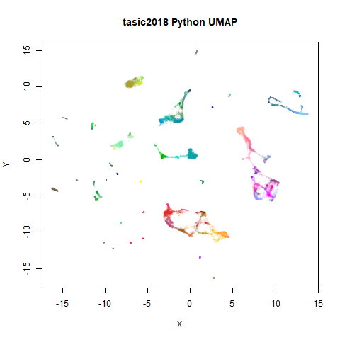

### macosko2015

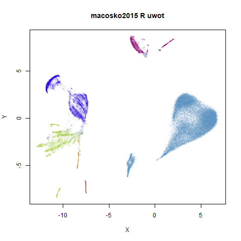

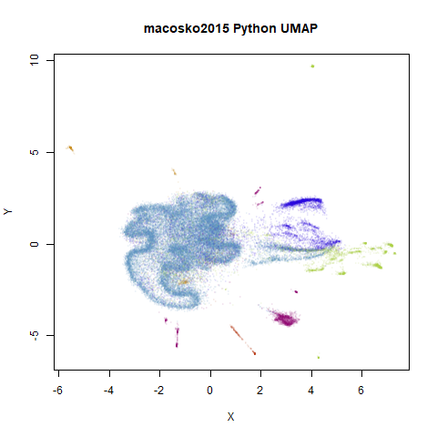

This result shows the largest deviation of `uwot` from `UMAP`. That big cyan cluster is of an obviously different shape in the two plots. The source of the difference here seems to be nearest neighbor results. It turns out that both `uwot` and `UMAP` have trouble find good approximations to the nearest neighbors with this dataset, but `UMAP` does a lot better. We will get into more detail about the nearest neighbor accuracies across the datasets in the next section. For now, below are two further plots. The left-hand plot is the `uwot` results when it uses the more accurate nearest neighbor data calculated by `UMAP`: the `uwot` results now resemble the `UMAP` results, which is reassuring. The right hand plot uses exact nearest neighbor results calculated via the `FNN`.

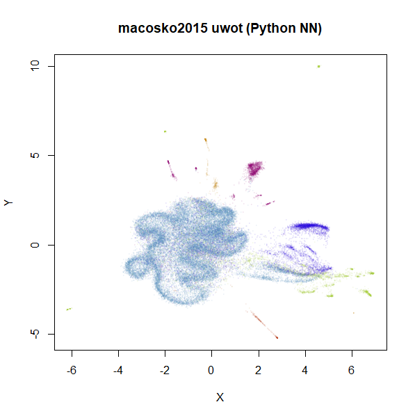

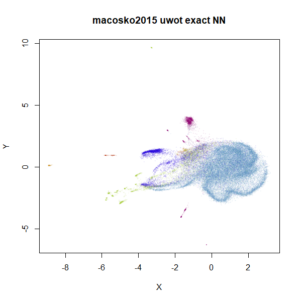

Even though the `UMAP` nearest neighbor data is better than that which `uwot` produced, we can still see an obvious difference in the two plots, so it’s clear that this data set presents a challenge for the approximate nearest neighbor methods considered here.

### cifar10

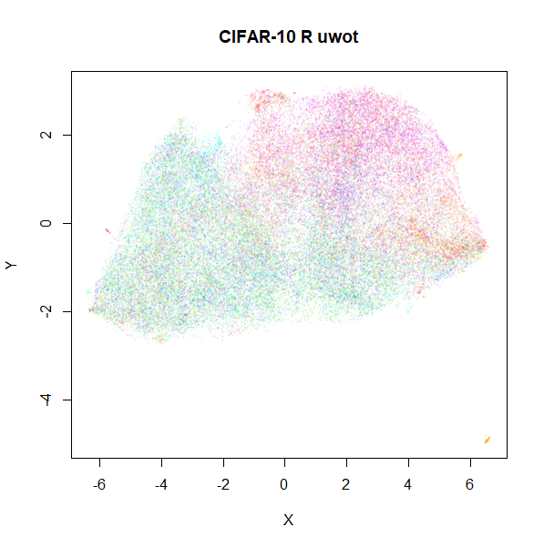

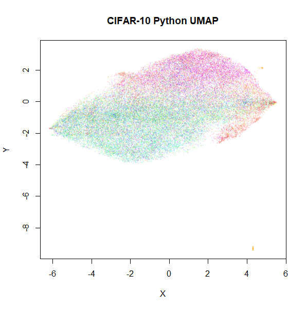

Based on results with this dataset in the [UMAP examples gallery](https://jlmelville.github.io/uwot/umap-examples.html), I wasn’t expecting these results to be a feast for the eyes. After seeing the difference in results with `macosko2015`, I am just relieved that these two results look disappointing in a similar way.